# Tidyverse CREATE

Moiya Josephs

4/9/2022

# GGPLOT

Is a package in `ggplot` that allows us to visualize our data and make it clearer when presenting our findings. In this document I plan to show how to use ggplot features that are not just bar plots or line charts. The data I will be using to demo the different features of ggplot is one that rates Ramen. It allows me to show how ggplot graphs discrete and continuous variables.

# Read Data

```r
ramen_ratings <- read.csv("https://raw.githubusercontent.com/moiyajosephs/Data607-Project2/main/ramen-ratings.csv")
```

## Plot Ramen

### Geom Count

When plotting two discrete variables `geom_count` is recommended. `Geom_Count` is a variation of `geom_point` and maps the frequency for each observation. It has a legend for the dots, the larger the dot the more of that value there is in the data.

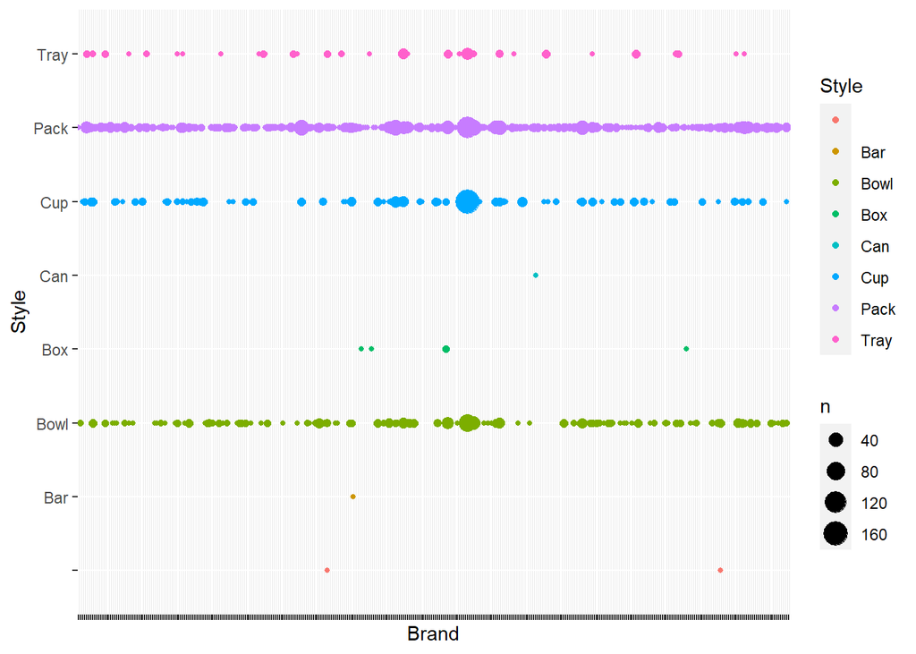

```r
ggplot(ramen_ratings, aes(Brand, Style, color = Style)) + geom_count() + theme(axis.text.x = element_blank() )
```

## Geom Col

`Geom col` is identical to geom_bar since it shows bar charts. The difference with `geom_col` is that it allows you to plot the bars relative to the data instead of the number of types x occurs like `geom_bar`.

Below I am able to plot the brand of ramen and the ratings they received.

```r
ramen_ratings$Stars <- as.numeric(ramen_ratings$Stars)
```

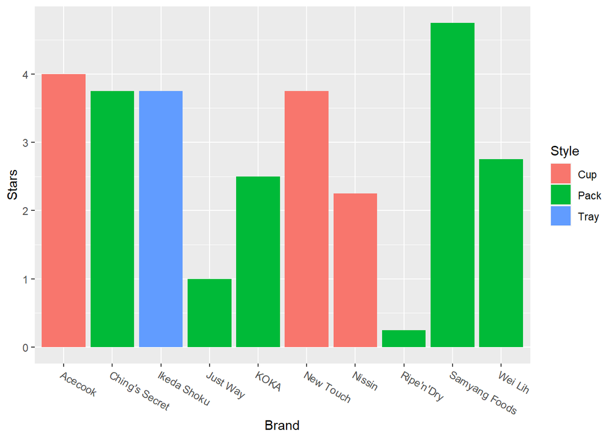

```r
ggplot(head(ramen_ratings,10), aes(Brand, Stars, fill = Style) ) + geom_col() +  theme(axis.text.x = element_text(angle = -30, vjust = 1, hjust = 0))
```